# Analysis of Damage of Weather

Xiang

January 9, 2017

## Synopsis

This project involves exploring the U.S. National Oceanic and Atmospheric Administration’s (NOAA) storm database. This database tracks characteristics of major storms and weather events in the United States, including when and where they occur, as well as estimates of any fatalities, injuries, and property damage. This study will show which types of events are most harmful with respect to population health and greatest economic consequences.

## Data Processing

1. Load required libraries and load the raw data that is provided by the Course, and then only include useful data.

```r
#peak Raw data
str(RawData)
```

```
## 'data.frame':    902297 obs. of  37 variables:
##  $ STATE__   : num  1 1 1 1 1 1 1 1 1 1 ...
##  $ BGN_DATE  : Factor w/ 16335 levels "1/1/1966 0:00:00",..: 6523 6523 4242 11116 2224 2224 2260 383 3980 3980 ...
##  $ BGN_TIME  : Factor w/ 3608 levels "00:00:00 AM",..: 272 287 2705 1683 2584 3186 242 1683 3186 3186 ...
##  $ TIME_ZONE : Factor w/ 22 levels "ADT","AKS","AST",..: 7 7 7 7 7 7 7 7 7 7 ...
##  $ COUNTY    : num  97 3 57 89 43 77 9 123 125 57 ...
##  $ COUNTYNAME: Factor w/ 29601 levels "","5NM E OF MACKINAC BRIDGE TO PRESQUE ISLE LT MI",..: 13513 1873 4598 10592 4372 10094 1973 23873 24418 4598 ...
##  $ STATE     : Factor w/ 72 levels "AK","AL","AM",..: 2 2 2 2 2 2 2 2 2 2 ...
##  $ EVTYPE    : Factor w/ 985 levels "   HIGH SURF ADVISORY",..: 834 834 834 834 834 834 834 834 834 834 ...
##  $ BGN_RANGE : num  0 0 0 0 0 0 0 0 0 0 ...
##  $ BGN_AZI   : Factor w/ 35 levels "","  N"," NW",..: 1 1 1 1 1 1 1 1 1 1 ...
##  $ BGN_LOCATI: Factor w/ 54429 levels "","- 1 N Albion",..: 1 1 1 1 1 1 1 1 1 1 ...
##  $ END_DATE  : Factor w/ 6663 levels "","1/1/1993 0:00:00",..: 1 1 1 1 1 1 1 1 1 1 ...
##  $ END_TIME  : Factor w/ 3647 levels ""," 0900CST",..: 1 1 1 1 1 1 1 1 1 1 ...
##  $ COUNTY_END: num  0 0 0 0 0 0 0 0 0 0 ...
```

[output cut: 23 more lines]

```r
#clean data, and keep columns will use in the analysis only
Data <- RawData %>%
  filter( EVTYPE != "?"
          & (FATALITIES > 0 | INJURIES > 0 |  PROPDMG > 0 | CROPDMG > 0)) %>%
  select(EVTYPE,
         FATALITIES,
         INJURIES,
         PROPDMG,
         PROPDMGEXP,
         CROPDMG,
         CROPDMGEXP)
#Peak cleaned Data
str(Data)
```

```
## 'data.frame':    254632 obs. of  7 variables:
##  $ EVTYPE    : Factor w/ 985 levels "   HIGH SURF ADVISORY",..: 834 834 834 834 834 834 834 834 834 834 ...
##  $ FATALITIES: num  0 0 0 0 0 0 0 0 1 0 ...
##  $ INJURIES  : num  15 0 2 2 2 6 1 0 14 0 ...
##  $ PROPDMG   : num  25 2.5 25 2.5 2.5 2.5 2.5 2.5 25 25 ...
##  $ PROPDMGEXP: Factor w/ 19 levels "","-","?","+",..: 17 17 17 17 17 17 17 17 17 17 ...
##  $ CROPDMG   : num  0 0 0 0 0 0 0 0 0 0 ...
##  $ CROPDMGEXP: Factor w/ 9 levels "","?","0","2",..: 1 1 1 1 1 1 1 1 1 1 ...
```

2.Manully mapping eventtype into ten major categories

```r
###Data Mapping
#Make everything upper case
Data$EVTYPE <- toupper(Data$EVTYPE)

#grouping keywords into 10 major categories.
Data$EVTYPE <- gsub('.*COLD.*', 'COLD', Data$EVTYPE)
Data$EVTYPE <- gsub('.*SNOW.*', 'COLD', Data$EVTYPE)
Data$EVTYPE <- gsub('.*FREEZ.*', 'COLD', Data$EVTYPE)
Data$EVTYPE <- gsub('.*WINTER.*', 'COLD', Data$EVTYPE)
Data$EVTYPE <- gsub('.*HYPOTHERMIA.*', 'COLD', Data$EVTYPE)
Data$EVTYPE <- gsub('.*ICY.*', 'COLD', Data$EVTYPE)
Data$EVTYPE <- gsub('.*LOW TEMPERATURE RECORD.*', 'COLD', Data$EVTYPE)
Data$EVTYPE <- gsub('.*ICE.*', 'COLD', Data$EVTYPE)
Data$EVTYPE <- gsub('.*FROST.*', 'COLD', Data$EVTYPE)
Data$EVTYPE <- gsub('.*LO.*TEMP.*', 'COLD', Data$EVTYPE)
Data$EVTYPE <- gsub('.*WINTRY.*', 'COLD', Data$EVTYPE)
Data$EVTYPE <- gsub('.*MIXED PRECIP.*', 'COLD', Data$EVTYPE)
Data$EVTYPE <- gsub('.*GLAZE.*', 'COLD', Data$EVTYPE)

Data$EVTYPE <- gsub('.*HEAT.*', 'HEAT', Data$EVTYPE)
Data$EVTYPE <- gsub('.*WARM.*', 'HEAT', Data$EVTYPE)
Data$EVTYPE <- gsub('.*HIGH.*TEMP.*', 'HEAT', Data$EVTYPE)
Data$EVTYPE <- gsub('.*EXTREME HEAT.*', 'HEAT', Data$EVTYPE)
Data$EVTYPE <- gsub('.*HYPERTHERMIA.*', 'HEAT', Data$EVTYPE)
Data$EVTYPE <- gsub('.*DROUGHT.*', 'HEAT', Data$EVTYPE)
Data$EVTYPE <- gsub('.*DRY.*', 'HEAT', Data$EVTYPE)

Data$EVTYPE <- gsub('.*HURRICANE.*', 'WIND', Data$EVTYPE)
Data$EVTYPE <- gsub('.*WIND.*', 'WIND', Data$EVTYPE)
Data$EVTYPE <- gsub('.*TYPHOON.*', 'WIND', Data$EVTYPE)
Data$EVTYPE <- gsub('.*MICROBURST.*', 'WIND', Data$EVTYPE)
Data$EVTYPE <- gsub('.*TROPICAL DEPRESSION.*', 'WIND', Data$EVTYPE)
Data$EVTYPE <- gsub('.*TURBULENCE.*', 'WIND', Data$EVTYPE)
Data$EVTYPE <- gsub('.*DOWNBURST.*', 'WIND', Data$EVTYPE)
Data$EVTYPE <- gsub('.*GUSTNADO.*', 'WIND', Data$EVTYPE)
Data$EVTYPE <- gsub('.*CURRENT.*', 'WIND', Data$EVTYPE)
Data$EVTYPE <- gsub('.*TSTMW.*', 'WIND', Data$EVTYPE)

Data$EVTYPE <- gsub('.*TIDE.*', 'WATER', Data$EVTYPE)
Data$EVTYPE <- gsub('.*SURF.*', 'WATER', Data$EVTYPE)
Data$EVTYPE <- gsub('.*FLOOD.*', 'WATER', Data$EVTYPE)
Data$EVTYPE <- gsub('.*WATER.*', 'WATER', Data$EVTYPE)
Data$EVTYPE <- gsub('.*SEA.*', 'WATER', Data$EVTYPE)
Data$EVTYPE <- gsub('.*TSUNAMI.*', 'WATER', Data$EVTYPE)
Data$EVTYPE <- gsub('.*DROWNING.*', 'WATER', Data$EVTYPE)
Data$EVTYPE <- gsub('.*SEICHE.*', 'WATER', Data$EVTYPE)
Data$EVTYPE <- gsub('.*DAM BREAK.*', 'WATER', Data$EVTYPE)
Data$EVTYPE <- gsub('.*HIGH.*', 'WATER', Data$EVTYPE)
Data$EVTYPE <- gsub('.*WAVE.*', 'WATER', Data$EVTYPE)

Data$EVTYPE <- gsub('.*STORM.*', 'WEATHER', Data$EVTYPE)
Data$EVTYPE <- gsub('.*HAIL.*', 'WEATHER', Data$EVTYPE)
Data$EVTYPE <- gsub('.*BLIZZARD.*', 'WEATHER', Data$EVTYPE)
Data$EVTYPE <- gsub('.*RAIN.*', 'WEATHER', Data$EVTYPE)
Data$EVTYPE <- gsub('.*FOG.*', 'WEATHER', Data$EVTYPE)
Data$EVTYPE <- gsub('.*SMOKE.*', 'WEATHER', Data$EVTYPE)
Data$EVTYPE <- gsub('.*CLOUD.*', 'WEATHER', Data$EVTYPE)
Data$EVTYPE <- gsub('.*DUST.*', 'WEATHER', Data$EVTYPE)
Data$EVTYPE <- gsub('.*SLEET.*', 'WEATHER', Data$EVTYPE)
Data$EVTYPE <- gsub('.*LIGNTNING.*', 'WEATHER', Data$EVTYPE)
Data$EVTYPE <- gsub('.*LIGHTNING.*', 'WEATHER', Data$EVTYPE)
Data$EVTYPE <- gsub('.*LIGHTING.*', 'WEATHER', Data$EVTYPE)
Data$EVTYPE <- gsub('.*WET.*', 'WEATHER', Data$EVTYPE)
Data$EVTYPE <- gsub('.*HEAVY.*', 'WEATHER', Data$EVTYPE)

Data$EVTYPE <- gsub('.*TORNADO.*', 'TORNADO', Data$EVTYPE)
Data$EVTYPE <- gsub('.*LANDSPOUT.*', 'TORNADO', Data$EVTYPE)
Data$EVTYPE <- gsub('.*TORNDAO.*', 'TORNADO', Data$EVTYPE)

Data$EVTYPE <- gsub('.*FIRE.*', 'FIRE', Data$EVTYPE)
Data$EVTYPE <- gsub('.*SLIDE.*', 'Geological', Data$EVTYPE)
Data$EVTYPE <- gsub('.*EROSION.*', 'Geological', Data$EVTYPE)
Data$EVTYPE <- gsub('.*VOLCANIC.*', 'Geological', Data$EVTYPE)
Data$EVTYPE <- gsub('.*AVALANCHE.*', 'Geological', Data$EVTYPE)
Data$EVTYPE <- gsub('.*AVALANCE.*', 'Geological', Data$EVTYPE)
Data$EVTYPE <- gsub('.*COASTAL SURGE.*', 'Geological', Data$EVTYPE)
Data$EVTYPE <- gsub('.*LANDSLUMP.*', 'Geological', Data$EVTYPE)
Data$EVTYPE <- gsub('.*APACHE COUNTY.*', 'Geological', Data$EVTYPE)

Data$EVTYPE <- gsub('.*MARINE.*', 'HUMAN', Data$EVTYPE)
Data$EVTYPE <- gsub('.*URBAN.*', 'HUMAN', Data$EVTYPE)


unique(Data$EVTYPE)
```

[output not shown]

## Result

1.Added a calculated field for health damage, and pre-aggregated the result, and then plot

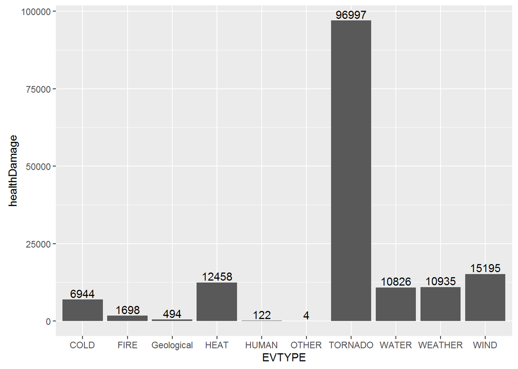

```r
#Graph 1
Data <- Data %>% mutate(health = FATALITIES + INJURIES)

Graph1 <- Data %>%
  group_by(EVTYPE) %>%
  select(health,EVTYPE) %>%
  summarise(
    healthDamage = sum(health, na.rm = TRUE)
  )

Plot1 <- ggplot(Graph1, aes(x= EVTYPE, y= healthDamage))+
  geom_bar(stat = "identity",position = "dodge") +
  geom_text(aes(label =healthDamage),
            position=position_dodge(width=0.9), vjust=-0.25)

Plot1
```

2.Clean up the exponential, added a calculated field for economic damage, and pre-aggregated the result, and then plot

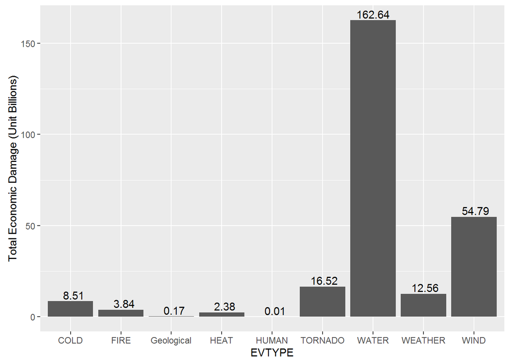

```r
#Graph 2
Data$PROPDMGEXP <- toupper(Data$PROPDMGEXP)
Data$CROPDMGEXP <- toupper(Data$CROPDMGEXP)

Data <- Data %>%
  filter(PROPDMGEXP %in% c("M","K","H","B"))

Data <- Data %>%
  filter(CROPDMGEXP %in% c("M","K","H","B"))

Data$PROPDMGEXP <- gsub("H", 10^2, Data$PROPDMGEXP)
Data$PROPDMGEXP <- gsub("K", 10^3, Data$PROPDMGEXP)
Data$PROPDMGEXP <- gsub("M", 10^6, Data$PROPDMGEXP)
Data$PROPDMGEXP <- gsub("B", 10^9, Data$PROPDMGEXP)

Data$CROPDMGEXP <- gsub("H", 10^2, Data$CROPDMGEXP)
Data$CROPDMGEXP <- gsub("K", 10^3, Data$CROPDMGEXP)
Data$CROPDMGEXP <- gsub("M", 10^6, Data$CROPDMGEXP)
Data$CROPDMGEXP <- gsub("B", 10^9, Data$CROPDMGEXP)

Data$PROPDMGEXP <- as.numeric(Data$PROPDMGEXP)
Data$CROPDMGEXP <- as.numeric(Data$CROPDMGEXP)

Data <- Data %>%
  mutate(Economic = PROPDMG * PROPDMGEXP + CROPDMG * CROPDMGEXP)


Graph2 <- Data %>%
  group_by(EVTYPE) %>%
  select(Economic,EVTYPE) %>%
  summarise(
    EconomicDamage = sum(Economic, na.rm = TRUE)
  )

Plot2 <- ggplot(Graph2, aes(x= EVTYPE, y= EconomicDamage/10^9))+
  geom_bar(stat = "identity",position = "dodge") +
  geom_text(aes(label =format(round(EconomicDamage/10^9, 2), nsmall = 2) ),
            position=position_dodge(width=0.9), vjust=-0.25) +
  ylab("Total Economic Damage (Unit Billions)")

Plot2
```

## Summary

Based on the analysis, the ‘Tornado’ is the major fact that causes the health damage. and ‘Water’ is the major fact that causes the economic damage.